# Estatística: A Ciência das Escolhas Instruções do Projeto

## Informações Adicionais

Em um teste Stroop, participantes são apresentados com uma lista de palavras, e cada uma das palavras está de uma cor. A tarefa dos participantes é dizer em voz alta a cor em que a palavra foi exibida.  
A tarefa tem duas condições: uma condição de palavras congruentes e uma condição de palavras incongruentes. Na condição de palavras congruentes, a palavra exibida são nomes de cores cujo os nomes são a mesma cor em que a palavra foi exibida: por exemplo, RED, BLUE.  
Na condição de palavras incongruentes, as palavras apresentadas são nomes de cores cujo os nomes não são as mesmas cores em que as palavras foram apresentadas; por exemplo, PURPLE, ORANGE. Em cada caso, medimos o tempo que demora para o indivíduo falar os nomes em uma lista das cores de de tamanhos iguais.  
Cada participante realizará o teste e tem o tempo medido para a realização do teste nas duas condições.

## Questões para Investigação

Como nota geral, tenha certeza que você está documentando todos os recursos que você está utilizando ou se refira a eles na criação do seu projeto. Você vai precisar reportar suas fontes como parte da submissão do projeto.

**1. Qual é a nossa variável independente? Qual é a nossa variável dependente?**  
A nossa variável independente é o conjunto de palavras em condição congruente e condição incongruente. Nossa variável dependente é o tempo de resposta que o indivíduo leva para falar o nome de cores em uma lista de tamanhos iguais (uma lista com palavras congruentes e uma lista com palavras incongruentes).  
**2. Qual seria um conjunto apropriado de hipóteses para essa tarefa? Que tipo de teste estatístico você espera executar? Justifique suas escolhas.**  
Iremos verificar se o tempo de resposta é afetado quando as palavras estão em condição incongruente, em relação às palavras congruentes. Portanto, nossa hipótese nula é que a média do tempo de resposta para palavras congruentes e incongruentes seja igual a 0. Por outro lado, a hipótese alternativa, na minha visão, é que a média do tempo de resposta das palavras incongruentes seja maior que a média do tempo de resposta das palavras congruentes.  
Portanto temos:  
$H_0$: $\mu_c >= \mu_i$  
$H_a$: $\mu_c < \mu_i$  
Por não termos os dados da população inteira (média e desvio padrão) e ter duas amostras pequenas, acredito que o correto seja executar o "t-test" para verificar a hipótese. Além disso, as amostras são dependentes: os elementos que fizeram o teste para as palavras congruentes, são os mesmos elementos que fizeram o teste para as palavras incongruentes.  
O teste será de uma cauda, conforme demonstrado na hipótese alternativa ($\mu_c < \mu_i$).

**3. Reporte alguma estatística descritiva em relação a esse conjunto de dados. Inclua, pelo menos, uma medida de tendência central de pelo menos uma medida de variabilidade.**

```python
from pandas import Series,DataFrame
import pandas as pd
import numpy as np
import seaborn as sns
import matplotlib.pyplot as plt
import math as m
%matplotlib inline
```

```python
data = pd.read_csv('stroopdata.csv')
```

```python
media_congruente = data["Congruent"].mean()
```

```python
media_incongruente = data["Incongruent"].mean()
```

```python
desvio_congruente = data["Congruent"].std()
```

```python
desvio_incongruente = data["Incongruent"].std()
```

```python
simple_data = {'Média Congruente':[media_congruente],
              'Desvio Congruente':[desvio_congruente],
              'Média Incongruente':[media_incongruente],
              'Desvio Incogruente':[desvio_incongruente]}
df_q3 = pd.DataFrame(simple_data)
df_q3
```

|  | Desvio Congruente | Desvio Incogruente | Média Congruente | Média Incongruente |
| --- | --- | --- | --- | --- |
| 0 | 3.559358 | 4.797057 | 14.051125 | 22.015917 |

```python
data.describe()
```

|  | Congruent | Incongruent |
| --- | --- | --- |
| count | 24.000000 | 24.000000 |
| mean | 14.051125 | 22.015917 |
| std | 3.559358 | 4.797057 |
| min | 8.630000 | 15.687000 |
| 25% | 11.895250 | 18.716750 |
| 50% | 14.356500 | 21.017500 |
| 75% | 16.200750 | 24.051500 |
| max | 22.328000 | 35.255000 |

**4. Forneça uma ou duas visualizações que mostre a distribuição da amostra de dados. Escreva uma ou duas sentenças sobre o que você observou do gráfico ou gráficos.**

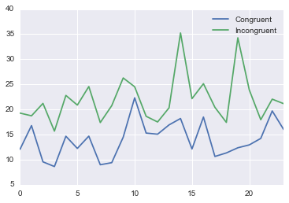

```python
data.plot()
```

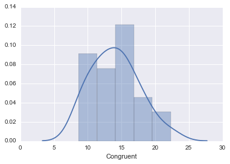

```python
sns.distplot(data['Congruent'])
```

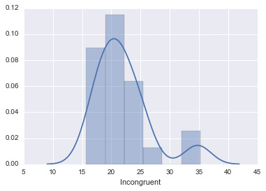

```python
sns.distplot(data['Incongruent'])
```

Os gráficos mostram a distribuição dos tempos de resposta. Ambos os gráficos parecem ter uma assimetria positiva.

**5. Agora desempenhe o teste estatístico e reporte seus resultados. Qual seu nível de confiança e o valor estatístico crítico? Você rejeitou a hipótese nula ou falhou ao tentar rejeitá-la? Encontre uma conclusão em relação ao experimento da tarefa. Os resultados estão de acordo com suas expectativas?**

Temos as seguintes informações:  
$\bar{X}c$ = 14.05  
$\bar{X}i$ = 22.01  
$S_c$ = 3.56  
$S_i$ = 4.80  
n = 24  
graus de liberdade (df) = 23  
$\alpha$ = 0.05  
$t_{critico}$ = -1.714  
Com isso temos todas as informações para executarmos o teste.

```python
data_diff = data['Congruent'] - data['Incongruent']
std_diff = data_diff.std()
SEM = std_diff/m.sqrt(data_diff.count())
```

```python
t = (media_congruente - media_incongruente)/SEM
t
```

```
-8.020706944109955
```

O resultado da estatística t é de aproximadamente -8.02. Este valor é menor do que o t crítico, e com isso rejeitamos a hipótese nula.  
Com isso temos um nível de confiança de 95% que o tempo médio de resposta para palavras incongruentes é maior que o tempo médio de resposta para palavras incongruentes. Os resultados estão de acordo com a minha expectativa inicial.

### Referências:

http://pages.stat.wisc.edu/~jgillett/327-1/RMarkdown.pdf  
https://www.udemy.com/learning-python-for-data-analysis-and-visualization/  
http://nbviewer.jupyter.org/github/jmportilla/Udemy-notes/tree/master/